# Using a Generalized SBM to quantify the difference between DTI and fMRI Connectomes in Bi-Lateral Connectivity

Eric Bridgeford

September 29, 2017

# Setting

## Task

Given:

- $n$ samples of graphs, $G_1 = \left\{(g_i)\right\}_{i=1}^n$ from one population, and $m$ samples of graphs, $G_2 = \left\{(g_i)\right\}_{i=1}^m$.
- A graph, $g_i \in G_j$, where $g_i = (E, V, w)$ for $N=|V|$ regions of interest and $w(v_i, v_j) = w_{ij}$.
- a partitioning of the edges into $E_1$ and $E_2$, where $E_1 \cup E_2 = E$ and $E_1 \cap E_2 = \emptyset$.
1. Does the connectivity for the edges $E_1$ exceed those of $E_2$ within a particular modality?
2. Does the difference in connectivity for the edges $E_1$ and $E_2$ of one modality exceed that of another modality?

## Statistical Model

Assume we have a random variable $A$ which can be characterized by the Stochastic Block Model with parameters $G$, $B$:

$$\begin{align*}
A \sim SBM(G, B)
\end{align*}$$

where $G$ is a grouping of the $N$ vertices in our graph into $C$ communities $V_i$ where $\bigcup\limits_{i=1}^{C} V_i = V$, and $V_i \cap V_j = \emptyset$ for all $i \neq j$. $B$ represents the parameters for within and between group edge probabilities. Assume that the number of edges in each subgraph are binomially distributed with the parameter $p$, we can estimate the number of edges for each group with the pmf (noting that in our case, we are given $n$ and $k$ a priori):

$$\begin{align*}
f_B(p | n, k) &= \begin{pmatrix}n \\ k\end{pmatrix}p^k (1 - p)^{n - k}
\end{align*}$$

Then the likelihood function is of the form:

$$\begin{align*}
L(p | n, k) &= \prod_{k=0}^n f_B(n, k | p) = \prod_{k=0}^n \begin{pmatrix}n \\ k\end{pmatrix}p^k (1 - p)^{n - k} \\
log(L(p | n, k)) &= \sum_{k=0}^n \log\left(\begin{pmatrix}n \\ k\end{pmatrix}\right) + k\log (p) + (n - k)\log (1 - p)
\end{align*}$$

Maximizing with respect to $p$:

$$\begin{align*}
\frac{\delta log(L(p | n, k))}{\delta p} &= \sum_{k=0}^n \frac{k}{p} - \frac{n - k}{1 - p} = 0 \\
\frac{k}{p} &= \frac{n - k}{1 - p} \\
\hat{p} &= \mathbb{E}[p] = \frac{k}{n}
\end{align*}$$

to get the variance term, we note that $\hat{p} = \frac{k}{n}$, so then $Var(p) = Var\left(\frac{k}{n}\right) = \frac{1}{n^2} Var(k)$. The binomial distriibution can be thought of as an aggregation of $n$ independent bernoulli trials with probability $p$; that is, $X_i \overset{iid}{\sim} Bern(p)$ where $\mathbb{E}\left[X_i\right] = p$. Given that the variance of independent events sum, we can expand:

$$\begin{align*}
Var(\sum_{i=1}^n X_i) &= \sum_{i=1}^n Var(X_i) = \sum_{i=1}^n E\left[X_i^2\right] - E\left[X_i\right]^2 \\
\mathbb{E}\left[X_i^2\right] &= 0^2(1-p) + 1^2(p) = p \\
Var(k) &= \sum_{i=1}^n \mathbb{E}\left[X_i^2\right] - \mathbb{E}\left[X_i\right]^2 \\
&= np(1-p)
\end{align*}$$

Then:

$$\begin{align*}
Var(\hat{p}) &= \frac{1}{n^2}Var(k) = \frac{\hat{p}(1-\hat{p})}{n}
\end{align*}$$

where $p$ is the probability of a given edge, $k$ are the number of connected edges, and $n$ is the number of possible edges. We can therefore define an estimator of $B$, $\hat{B}$ where connections between community $V_l$ and $V_m$ can be modelled iid:

$$\begin{align*}
\hat{B}_{lm} &= \mathcal{N}(\mu_{lm}, \sigma_{lm})
\end{align*}$$

where $\hat{\mu}_{lm} = \frac{1}{\left|C_l \times C_m\right|}\sum_{(i, j) \in E(C_l \times C_m)} A_{ij}$, and $\hat{\sigma}^2_{lm} = \frac{\hat{\mu}_{lm}(1 - \hat{\mu}_{lm})}{\left|C_l \times C_m\right|}$.

Assuming our edges are iid, we can generalize the above model very simply by instead of considering our vertices to exist in communities, placing our edges into two communities $E_1$ and $E_2$, where $E_1 \cup E_2 = E$ and $E_1 \cap E_2 = \emptyset$. We propose the structured independent-edge model:

$$\begin{align*}
A \sim SIEM(G, B)
\end{align*}$$

where $G$ is a grouping of our $N^2$ possible edges into $C$ communities $E_i$ where $\bigcup\limits_{i=1}^{C} E_i = E$, and $E_i \cap E_j = \emptyset$ for all $i \neq j$. $B$ represents the parameters for within and between group edge probabilities.

Then we can define an estimator for $B$ as follows:

$$\begin{align*}
\hat{B} \sim \mathcal{N}(\mu_B, \Sigma_B)
\end{align*}$$

where:

$$\begin{align*}
\mu_B^{(k)} &= p_k = \frac{1}{|E_k|} \sum_{(i, j) \in E_k} M_{ij} \\
\sigma_B^{(k)} &= \frac{p_k(1 - p_k)}{|E_k|}
\end{align*}$$

given some adjacency representation of a graph $M \in \left\{0, 1\right\}^{N \times N}$.

In a 2-community case (as studied here):

$$\begin{align*}
\hat{\mu}_B &= \begin{bmatrix}
p_{1} \\
p_{2}
\end{bmatrix} \\
\hat{\Sigma}_B &= \begin{bmatrix}
\frac{p_{1}(1 - p_{1})}{|E_1|} & 0 \\
0 & \frac{p_{2}(1 - p_{2})}{|E_2|}
\end{bmatrix} = \begin{bmatrix}
\sigma_{p_1} & 0 \\
0 & \sigma_{p_2}
\end{bmatrix}
\end{align*}$$

where $p_j$ represents the probability of an edge in the $j^{th}$ edge-community, and $\sigma_j$ the variance of edges in that particular edge-community. Then given a connectome as an adjacency matrix $M \in \left\{0, 1\right\}^{N \times N}$ with $N$ vertices, we can compute estimators as follows:

$$\begin{align*}
E_1 &= \left\{(i, j): \textrm{edge }(i, j) \in E_1\right\} \\
E_2 &= \left\{(i, j): \textrm{edge }(i, j) \in E_2\right\} \\
\hat{p}_1 &= \frac{1}{|E_1|} \sum_{(i, j) \in E_1} M_{ij} \\
\hat{p}_2 &= \frac{1}{|E_2|} \sum_{(i, j) \in E_2} M_{ij} \\
\sigma_{\hat{p}_1} &= s_1 = \frac{p_{1}(1 - p_{1})}{|E_1|} \\
\sigma_{\hat{p}_2} &= s_2 = \frac{p_{2}(1 - p_{2})}{|E_2|}
\end{align*}$$

Then we have $\delta = p_1 - p_2$ representing the difference in connectivity from $E_1$ to $E_2$. For these experiments, we will let $E_1$ be the bilateral edges, and $E_2$ the non-bilateral edges.

## Statistical Goal

Where $\delta_i$ is the difference in connectivity for the $i^{th}$ group of graphs, and $p_{j, i}$ the probability of an edge for the $j^{th}$ edge community in the $i^{th}$ group of graphs, let $H_0: \delta_1 <= \delta_2$, and $H_A: \delta_1 > \delta_2$, determine:

$$\begin{align*}
\mathbb{P}(\textrm{reject $H_0$ in favor of $H_A$ | $H_0$ is true})
\end{align*}$$

That is, determine the probability of incorrectly rejecting the null hypothesis that the difference in connectivity in the graphs of $G1$ is less than or equal to the difference in connectivity in the graphs of $G_2$.

For this notebook, we will investigate with $E_1$ as the bilateral edges, and $E_2$ as the non-bilateral edges.

## Test Statistic

[Welch’s T-Test](https://en.wikipedia.org/wiki/Welch%27s_t-test) for testing whether populations have equal means given that they have different variances in the univariate case.

$$\begin{align*}
T = \frac{\bar{\delta}_1 - \bar{\delta}_2}{\sqrt{\frac{s_1^2}{n_1} + \frac{s_2^2}{n_2}}}
\end{align*}$$

Since our random variables are all assumed to be independent (covariance terms are all zero), we can assume that $s_1^2 = \sigma_{\hat{\delta}_1}^2 = \sigma^2_{\hat{p}_1, 1} + \sigma^2_{\hat{p}_2, 1}$, and $s_2^2 = \sigma_{\hat{\delta}_2}^2 = \sigma^2_{\hat{p}_1, 2} + \sigma^2_{\hat{p}_2, 2}$.

and the degrees of freedom can be calculated as follows:

$$\begin{align*}
\nu &= \frac{\left(\frac{s_1^2}{n_1} + \frac{s_2^2}{n_2}\right)^2}{\frac{s_1^4}{n_1^2 \nu_1} + \frac{s_2^4}{n_2^2\nu_2}}
\end{align*}$$

where $\nu_1 = n_1 - 1, \; \nu_2 = n_2 - 1$.

We can then use a one-sided test given $T, \nu$ to get a $p-$ value.

## P-Value

1. We can compute a p-value of falsely rejecting the null hypothesis by simply finding the area:

$$\begin{align*}
p = \int_{-T_{observed}}^{\infty}p(x, df) dx = 1 - \int_{-\infty}^{T_{observed}} p(x, df) dx
\end{align*}$$

where $p(x, df)$ is the pdf for the $T$ distribution with degrees of freedom $df$.

## Statistical Power

1. The statistical power can be computed as the inverse of the probability of making a Type II ($\beta$) error, $1 - \beta$. A type II error can be defined as follows:

$$\begin{align*}
\beta = \mathbb{P}(\textrm{reject $H_A$ in favor of $H_0$ | $H_A$ is true}) = \mathbb{P}(T_{observed} < T_{critical})
\end{align*}$$

where $T_{critical}$ is the test-statistic at the given level of significance $\alpha$ specified by our test. To compute the power, we will compute the rejection cutoff for the test-statistic, and then simulate data under the alternative hypothesis, and see how many times we would reject the null hypothesis in our simulated data. In pseudo-code:

```r
Compute_Power(n, diffs, sig=.95):
  cutoff = T_{dist}(sig, df=n-2)
  tstat = []
  for i in 1:n
    # simulate 100 deltas from 2 populations of binomial edges
    snull = repeat(100 times, sum(random_binomial(ne, 0.5 + diffs[1]))/ne - sum(randim_binomial(ne, 0.5 - diffs[1]))/ne)
    # simulate 100 deltas from 2 populations of binomial edges, where diffs[2] > diffs[1]
    salt = repeat(100 times, sum(random_binomial(ne, 0.5 + diffs[2]))/ne - sum(randim_binomial(ne, 0.5 - diffs[2]))/ne)
    # determine whether difference in (0.5 + diffs[2] - (0.5 - diffs[2])) - (0.5 + diffs[1] - (0.5 - diffs[2])) is appreciable
    tstat[i] = welch_ttest(salt, snull, test="alt > null")$statistic
  end
  return(sum(ts > cutoff)/n)
```

# Simulations

To run the below code, the user must have several packages installed. From an R session, these can be installed with:

```r
install.packages(c('ggplot2', 'latex2exp', 'igraph', 'devtools'))
require(devtools)
install_github('neurodata/fmriutils')
```

## Simulated Data

### Consistency of Estimators for $\hat{\delta}$

Here, we will verify that our estimators of $\hat{\delta}$ are correct, that is, that we can accurately estimate $\mu_{\hat{\delta}}$ and $\sigma^2_{\hat{\delta}}$ given binomially distributed edges:

```r
# package dependencies -------------------
require(ggplot2)
library(latex2exp)
require(igraph)
require(fmriutils)
# Util functions ------------------------
# variance under the given model with params probability p, and number of edges n
model.var = function(p, n) {
  p*(1 - p)/n
}

# compute the mu and sigma params associated with an input array under the model
model.params = function(dat) {
  mu = sum(dat)/length(dat)
  var = model.var(mu)
  return(list(mu = mu, sigma = sqrt(var)))
}

# accepts a [n x n] adjacency matrix and computes the probabilities associated with an SBM
# where the vertices are grouped such that union_i(groups) = V(A) and
# intersection(group_i, group_j) = NULL for all i != j
block_data = function(matrix, groups) {
  # matrix is adwi_thresh n x n array
  # groups is a grouping of the vertices in the matrix as a list
  blocks = array(NaN, dim=c(2,2))
  for (i in 1:length(groups)) {
    for (j in 1:length(groups)) {
      blocks[i, j] = mean(matrix[groups[[i]], groups[[j]]])
    }
  }
  return(blocks)
}

# computes the analytical welch t-test given mu and the number of observations
# and the number of samples. Optionally accepts params for the degrees of freedom
# to override the default computation.
ana.welch_ttest = function(u1, u2, v1, v2, ns1=NaN, ns2=NaN, df=NaN, verbose=TRUE) {
  s1 = sqrt(v1)
  s2 = sqrt(v2)
  tstat = (u1 - u2)/sqrt(s1^2/ns1 + s2^2/ns2)
  if (!is.nan(df)) {
    df = df
  } else {
    dfnum = (s1^2/ns1 + s2^2/ns2)^2
    dfdenom = s1^4/(ns1^2*(ns1 - 1)) + s2^4/(ns2^2*(ns2-1))
    df = round(dfnum/dfdenom)
  }
  p = 1 - pt(tstat, df=df)
  return(list(t=tstat, p=p, df=df))
}

# computes the power of the model under a given significance level
# accepts params for a number of simulations to average power over, and a
# number of graphs for each computation
# number of edges defines the number of edges to use in the binomial simulation
t.power = function(diffs, ne=1225, sig=.95, nsim=100, ngr=100) {
  ucut = qt(sig, df=ngr)  # t-statistic of null at the given significance level with ne-2 degrees of freedom
  ts = replicate(nsim, {  # replicate our described test n tsim times
    alt = replicate(ngr, sum(rbinom(n = ne, size=1, prob = 0.5 + diffs[1]/2))/ne - sum(rbinom(n = ne, size=1, prob=0.5 - diffs[1]/2))/ne)
    null = replicate(ngr, sum(rbinom(n = ne, size=1, prob = 0.5 + diffs[2]/2))/ne - sum(rbinom(n = ne, size=1, prob = 0.5 - diffs[2]/2))/ne)
    t.test(alt, null, alternative = "greater", var.equal = FALSE)$statistic
  })
  v1 =  model.var(0.5 + diffs[1]/2, ne) + model.var(0.5 - diffs[1]/2, ne)
  v2  =  model.var(0.5 + diffs[2]/2, ne) + model.var(0.5 - diffs[2]/2, ne)
  ana_tstat = ana.welch_ttest(diffs[1], diffs[2], v1, v2,  ngr, ngr)$t
  return(list(power=sum(ts > ucut)/nsim, diff=abs(mean(ts) - ana_tstat)/ana_tstat))
}

# accepts a matrix and thresholds/binarizes it
thresh_matrix = function(matrix, thresh=0.5) {
  thr = quantile(matrix, thresh)
  return(ifelse(matrix > thr, 1, 0))
}
```

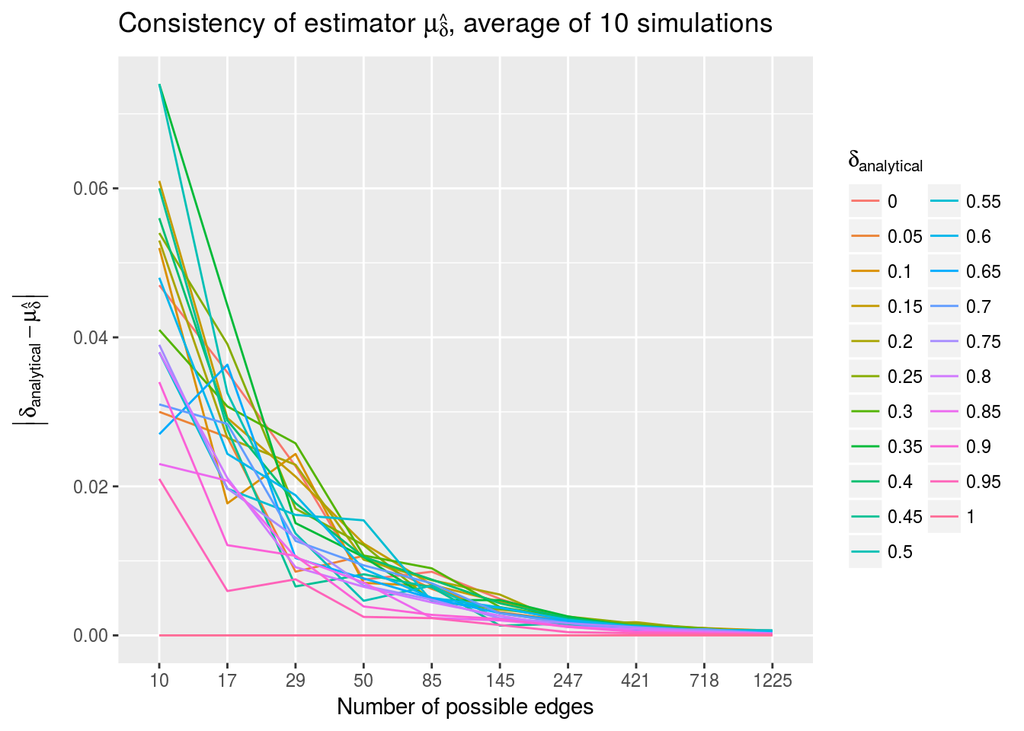

```r
ns = round(10^seq(1, log10(1225), length=10))
ds = seq(0, 1.0, length=21)
ndat = length(ns)*length(ds)
empty_ar = array(NaN, dim=c(ndat))
results = data.frame(n = empty_ar, d = empty_ar, mu = empty_ar, var = empty_ar)
counter = 1
nsim = 10
for (n in ns) {
  for (d in ds) {
    v_ar = array(NaN, dim=c(nsim))
    m_ar = array(NaN, dim=c(nsim))
    for (i in 1:nsim) {
      p1 = 0.5 + d/2
      p2 = 0.5 - d/2
      demp = replicate(n, {
        dat1 = rbinom(n = n, p = p1, size=1)
        dat2 = rbinom(n = n, p = p2, size=1)
        dhat = sum(dat1 - dat2)/length(dat1)
        })
      m_ar[i] = abs(mean(demp) - d)
      v_ar[i] = abs(var(demp) - (model.var(p1, n) + model.var(p2, n)))
    }
    results[counter,] = data.frame(n = n, d = d, mu = mean(m_ar),
                                   var = mean(v_ar))
    counter <- counter + 1
  }
}

results$n = factor(results$n)
results$d = factor(results$d)

ggplot(results, aes(x = n, y = mu, group=d, color=d)) +
  geom_line() +
  ggtitle(TeX('Consistency of estimator $\\mu_{\\hat{\\delta}}$, average of 10 simulations')) +
  xlab("Number of possible edges") +
  ylab(TeX('$\\left|\\delta_{analytical} - \\mu_{\\hat{\\delta}}\\right|$')) +
  scale_color_discrete(name=TeX("$\\delta_{analytical}$"))
```

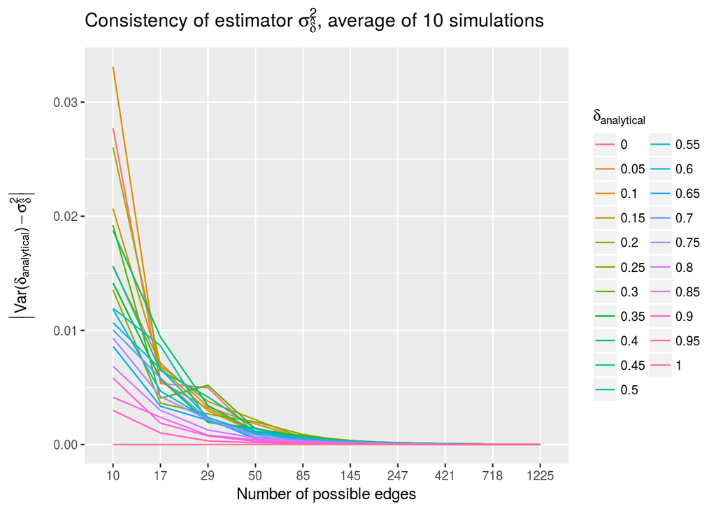

```r
ggplot(results, aes(x = n, y = var, group=d, color=d)) +
  geom_line() +
  ggtitle(TeX('Consistency of estimator $\\sigma^2_{\\hat{\\delta}}$, average of 10 simulations')) +
  xlab("Number of possible edges") +
  ylab(TeX('$\\left|Var(\\delta_{analytical}) - \\sigma^2_{\\hat{\\delta}}\\right|$')) +
  scale_color_discrete(name=TeX("$\\delta_{analytical}$"))
```

As we can see, as our number of possible edges increases, our estimators for $\mu$ and $\sigma^2$ converge, indicating we have consistent estimators.

### Simulated Trials

- Simulate $n$ graphs with edges from a binomial distribution given $ne, p + \epsilon_1$ and $ne, p - \epsilon_1$, the alternative samples.
- Simulate $n$ graphs with edges from a binomial distribution given $ne, p + \epsilon_2$ and $ne, p - \epsilon_2$, the null samples.
- Compute the empirical distribution for $\hat{p}$ for the alternative and null samples, respectively by repeating the above procedure $ns$ times.
- derive the power from the respective empirical distribution of $\hat{\delta}$ as the fraction of test statistics more extreme than the critical test statistic.
- compute the difference between the average simulated test statistic and the analytical test statistic.

```r
maxdiff = 0.2
diff = seq(0,  maxdiff, length=21)
ns = round(10^seq(1, log10(1225), length=10))
ndat = length(ns)*length(diff)
empty_ar = array(NaN, dim=c(ndat))
dat = data.frame(ns = empty_ar, diff=empty_ar, pow=empty_ar, tdiff=empty_ar)
counter = 1
for (j in 1:length(ns)) {
  n = ns[j]
  for (i in 1:length(diff)) {
    in.d = maxdiff + diff[i]/2
    out.d = maxdiff - diff[i]/2
    # under the model, assume the p_in is the mean within group, and p_out is the mean outside of group
    # compute the standard deviation according to the model
    diffs = c(in.d, out.d)
    result = t.power(diffs, ne=n)
    dat[counter,] = c(ns=n, diff=diff[i], pow=result$power, tdiff=result$diff)
    counter = counter + 1
  }
}
```

First, we look at power as a function of the number of edges in our simulation, as we vary the difference between the $\delta$ for each population of graphs:

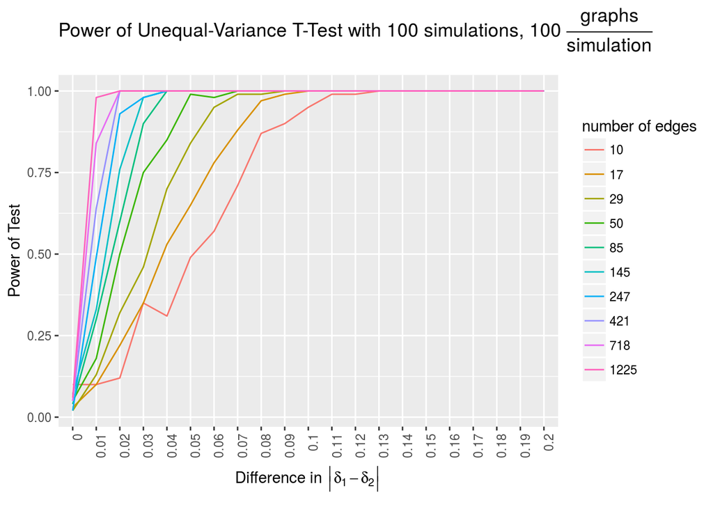

```r
dat$ns = factor(dat$ns)
dat$diff = factor(dat$diff)
thresh = data.frame(diff=diff, sig=.05)
thresh$diff = factor(thresh$diff)
ggplot(dat,  aes(x = diff, y = pow, group=ns, color=ns)) +
  geom_line() +
  ggtitle(TeX('Power of Unequal-Variance T-Test with 100 simulations, 100 $\\frac{graphs}{simulation}$')) +
  xlab(TeX('Difference in $\\left|\\delta_1 - \\delta_2\\right|$')) +
  ylab('Power of Test') +
  scale_color_discrete(name="number of edges") +
  theme(axis.text.x = element_text(angle = 90, hjust = 1))
```

And we also look at how the analytical test-statistic computed from our trials compares to the empirical test-statistics estimated from our simulation procedure:

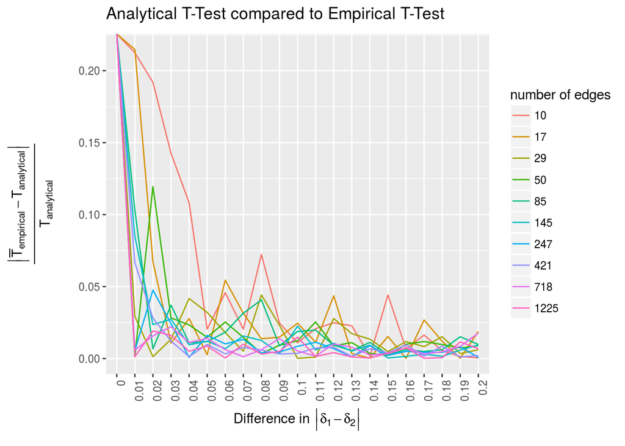

```r
ggplot(dat, aes(x = diff, y = tdiff, group=ns, color=ns)) +
  geom_line() +
  ggtitle(TeX('Analytical T-Test compared to Empirical T-Test')) +
  xlab(TeX('Difference in $\\left|\\delta_1 - \\delta_2\\right|$')) +
  ylab(TeX('$\\frac{\\left|\\bar{T}_{empirical} - T_{analytical}\\right|}{T_{analytical}}')) +
  scale_color_discrete(name="number of edges") +
  theme(axis.text.x = element_text(angle = 90, hjust = 1))
```

# Real Data Experiments

## Raw Data

For the data, we compute the weighted mean functional (rank of each edge) and diffusion (number of fibers). For the functional connectome, we threshold such that the largest 50% of edges are set to connected, and the smallest 50% set to disconnected. For the diffusion (which are natively sparse) we just threshold edges that are present to connected, and edges that are not present to disconnected (threshold about 0).

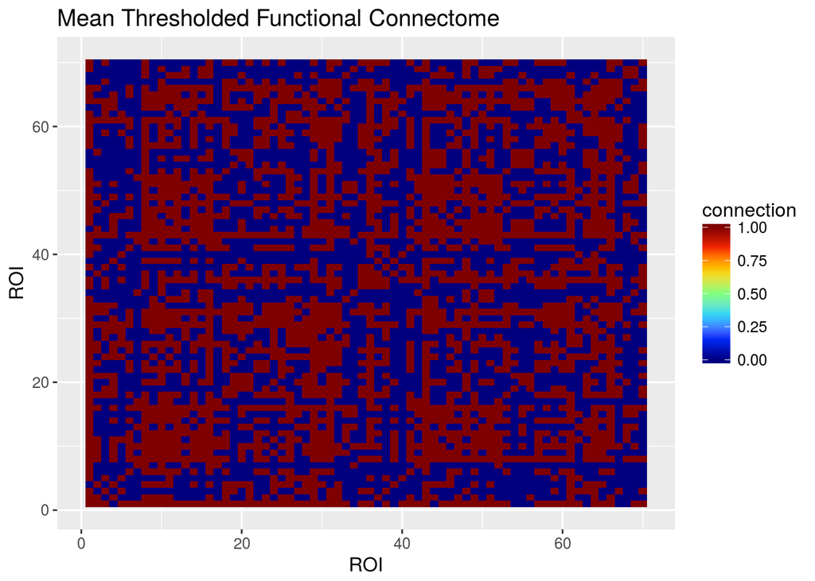

```r
basepath = '/data/connectome_stats/'
fmri_gr = read_graph(file.path(basepath, 'fmrimean_1709.edgelist'), format="ncol")
fmri_mean = get.adjacency(fmri_gr, type="both", sparse=FALSE, attr='weight')
dwi_gr = read_graph(file.path(basepath, 'dwimean_2861.edgelist'), format="ncol")
dwi_mean = get.adjacency(dwi_gr, type="both", sparse=FALSE, attr='weight')

fmri_thresh = thresh_matrix(fmri_mean)
dwi_thresh = thresh_matrix(dwi_mean, thresh=0)

fmriu.plot.plot_graph(fmri_thresh, include_diag = TRUE, title = "Mean Thresholded Functional Connectome", legend.name = "connection")
```

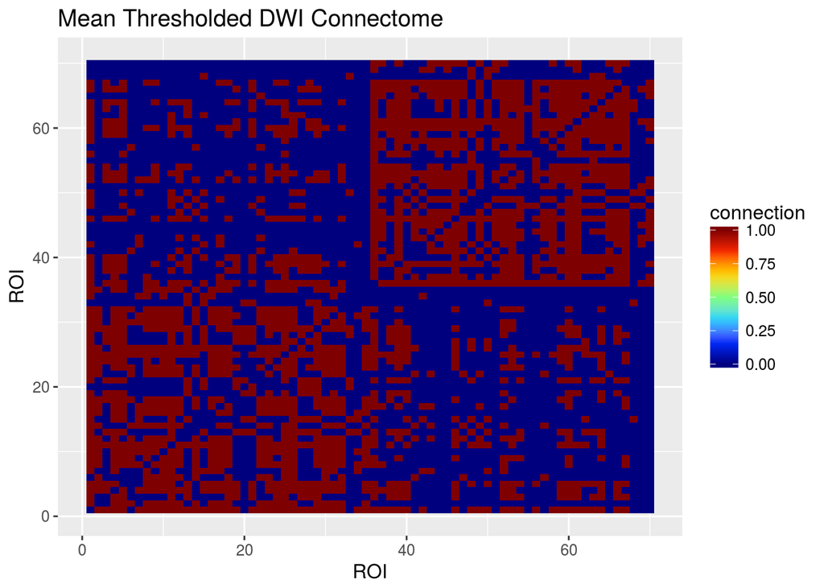

```r
fmriu.plot.plot_graph(dwi_thresh, include_diag = TRUE, title = "Mean Thresholded DWI Connectome", legend.name = "connection")
```

```r
group1 = c()
group2 = c()
# loop over all possible edges to get the indices we want to examine
for (i in 1:70) {
  for (j in 1:70) {
    idx = i + 70*(j - 1)
    if (abs(i - j) == 35) {  # if this is a bi-lateral edge
      group1 <- c(group1, idx)
    } else if (i != j) {
      group2 <- c(group2, idx)
    }  # don't count self-loops
  }
}
```

## Difference in Bi-Lateral vs. Non Bi-Lateral Connectivity

### Comparing Distributions of Functional and Diffusion $\hat{\delta}$ (one p-value total)

Here, we take each functional and diffusion connectome individually, and compute the parameters of our block model for each connectome. The question we seek to first answer is, given a large number of observations of $\hat{\delta}$, can we detect when bilateral connectivity exceeds non-bilateral connectivity in the functional connectomes compared to the diffusion connectomes?

#### Diffusion

```r
dwi.dsets = c('BNU1', 'BNU3', 'HNU1', 'KKI2009', 'NKI1', 'NKIENH', 'MRN1313', 'Templeton114', 'Templeton255', 'SWU4')
dwi.atlas = 'desikan'
dwi.basepath = '/data/dwi/edgelists/'

graphobj = fmriu.io.collection.open_graphs(basepath = dwi.basepath, atlases = dwi.atlas, datasets = dwi.dsets,
                                           gname = 'graphs', fmt='edgelist', rtype = 'array')
```

```
## [1] "opening graphs for BNU1 dataset and desikan parcellation atlas..."
## [1] "opening graphs for BNU3 dataset and desikan parcellation atlas..."
## [1] "opening graphs for HNU1 dataset and desikan parcellation atlas..."
## [1] "opening graphs for KKI2009 dataset and desikan parcellation atlas..."
## [1] "opening graphs for NKI1 dataset and desikan parcellation atlas..."
## [1] "opening graphs for NKIENH dataset and desikan parcellation atlas..."
## [1] "opening graphs for MRN1313 dataset and desikan parcellation atlas..."
## [1] "opening graphs for Templeton114 dataset and desikan parcellation atlas..."
## [1] "opening graphs for Templeton255 dataset and desikan parcellation atlas..."
## [1] "opening graphs for SWU4 dataset and desikan parcellation atlas..."
```

```r
dwi.graphs = graphobj$graphs
dwi.datasets = graphobj$dataset
dwi.subjects = graphobj$subjects
```

```r
ne = 1225
bi.phat = array(NaN, dim=c(dim(dwi.graphs)[1]))
nbi.phat = array(NaN, dim=c(dim(dwi.graphs)[1]))
dwi.per.var = array(NaN, dim=c(dim(dwi.graphs)[1]))
for (i in 1:dim(dwi.graphs)[1]) {
  gr = thresh_matrix(dwi.graphs[i,,], thresh=0)
  bi = c(gr[group1])
  nbi = c(gr[group2])
  bi.phat[i] = mean(bi)
  nbi.phat[i] = mean(nbi)
  dwi.per.var[i] = model.var(bi.phat[i], ne) + model.var(nbi.phat[i], ne)
}
dwi.delta = abs(bi.phat - nbi.phat)
dwi.mu = mean(dwi.delta)
dwi.var = model.var(mean(bi.phat), ne) + model.var(mean(nbi.phat), ne)
```

#### Functional

```r
fmri.dsets = c('BNU1', 'BNU2', 'BNU3', 'HNU1', 'IBATRT', 'IPCAS1', 'IPCAS2', 'IPCAS5', 'IPCAS6', 'IPCAS8', 'MRN1', 'NYU1', 'SWU1', 'SWU2', 'SWU3', 'SWU4', 'UWM', 'XHCUMS')
fmri.atlas = 'desikan-2mm'
fmri.basepath = '/data/fmri/ranked/edgelists/'

graphobj = fmriu.io.collection.open_graphs(basepath = fmri.basepath, atlases = fmri.atlas, datasets=fmri.dsets, fmt='edgelist', rtype = 'array')
```

```
## [1] "opening graphs for BNU1 dataset and desikan-2mm parcellation atlas..."
## [1] "opening graphs for BNU2 dataset and desikan-2mm parcellation atlas..."
## [1] "opening graphs for BNU3 dataset and desikan-2mm parcellation atlas..."
## [1] "opening graphs for HNU1 dataset and desikan-2mm parcellation atlas..."
## [1] "opening graphs for IBATRT dataset and desikan-2mm parcellation atlas..."
## [1] "opening graphs for IPCAS1 dataset and desikan-2mm parcellation atlas..."
## [1] "opening graphs for IPCAS2 dataset and desikan-2mm parcellation atlas..."
## [1] "opening graphs for IPCAS5 dataset and desikan-2mm parcellation atlas..."
## [1] "opening graphs for IPCAS6 dataset and desikan-2mm parcellation atlas..."
## [1] "opening graphs for IPCAS8 dataset and desikan-2mm parcellation atlas..."
## [1] "opening graphs for MRN1 dataset and desikan-2mm parcellation atlas..."
## [1] "opening graphs for NYU1 dataset and desikan-2mm parcellation atlas..."
## [1] "opening graphs for SWU1 dataset and desikan-2mm parcellation atlas..."
## [1] "opening graphs for SWU2 dataset and desikan-2mm parcellation atlas..."
## [1] "opening graphs for SWU3 dataset and desikan-2mm parcellation atlas..."
## [1] "opening graphs for SWU4 dataset and desikan-2mm parcellation atlas..."
## [1] "opening graphs for UWM dataset and desikan-2mm parcellation atlas..."
## [1] "opening graphs for XHCUMS dataset and desikan-2mm parcellation atlas..."
```

```r
fmri.graphs = graphobj$graphs
fmri.datasets = graphobj$dataset
fmri.subjects = graphobj$subjects
```

```r
bi.phat = array(NaN, dim=c(dim(fmri.graphs)[1]))
nbi.phat = array(NaN, dim=c(dim(fmri.graphs)[1]))
fmri.per.var = array(NaN, dim=c(dim(fmri.graphs)[1]))
for (i in 1:dim(fmri.graphs)[1]) {
  gr = thresh_matrix(fmri.graphs[i,,])
  bi = c(gr[group1])
  nbi = c(gr[group2])
  bi.phat[i] = mean(bi)
  nbi.phat[i] = mean(nbi)
  fmri.per.var[i] = model.var(bi.phat[i], ne) + model.var(nbi.phat[i], ne)
}
fmri.delta = abs(bi.phat - nbi.phat)
fmri.mu = mean(fmri.delta)
fmri.var = model.var(mean(bi.phat), ne) + model.var(mean(nbi.phat), ne)
```

We might want to visualize the distribution of $\delta = \hat{p}_{bi} - \hat{p}_{non-bi}$ under the analytical model and compare to our empirical model for functional and diffusion:

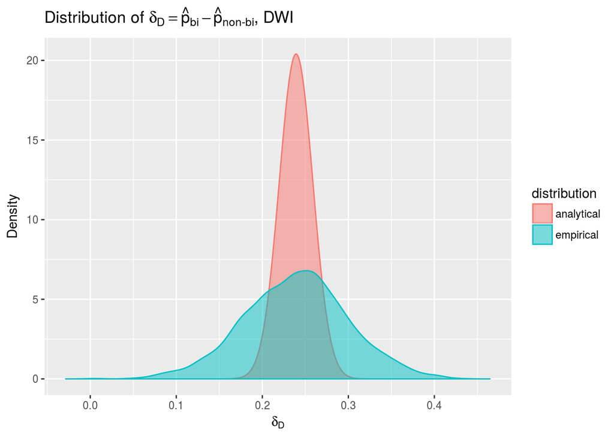

```r
ne = 1225
# density estimates of the two populations of delta
dwi.distr.emp.mod = density(as.numeric(dwi.delta))
fmri.distr.emp.mod = density(as.numeric(fmri.delta))

# variances sum for analytical computation
dwi.distr.ana = dnorm(dwi.distr.emp.mod$x, mean=dwi.mu, sd=sqrt(dwi.var))
fmri.distr.ana = dnorm(fmri.distr.emp.mod$x, mean=fmri.mu, sd=sqrt(fmri.var))

n_diff = length(dwi.distr.emp.mod$x)
dwi.dat = data.frame(x = c(dwi.distr.emp.mod$x, dwi.distr.emp.mod$x), y = c(dwi.distr.emp.mod$y, dwi.distr.ana),
                      distribution=c(rep("empirical", n_diff), rep("analytical", n_diff)))
dwi.dat$distribution = factor(dwi.dat$distribution)

ggplot(dat=dwi.dat, aes(x=x, y=y, ymax=y, fill=distribution, color=distribution, group=distribution)) +
  geom_ribbon(ymin=0, alpha=0.5) +
  ylab('Density') +
  xlab(TeX('$\\delta_D$')) +
  ggtitle(TeX('Distribution of $\\delta_D = \\hat{p}_{bi} - \\hat{p}_{non-bi}$, DWI'))
```

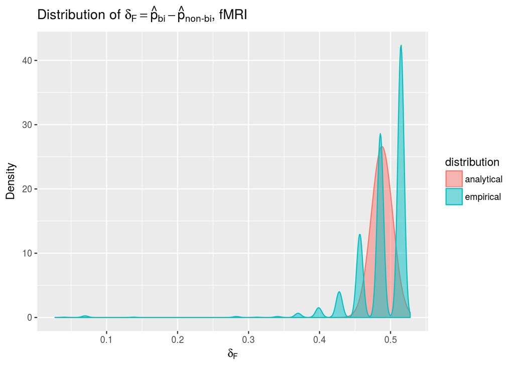

```r
n_diff = length(dwi.distr.emp.mod$x)
fmri.dat = data.frame(x = c(fmri.distr.emp.mod$x, fmri.distr.emp.mod$x), y = c(fmri.distr.emp.mod$y, fmri.distr.ana),
                      distribution=c(rep("empirical", n_diff), rep("analytical", n_diff)))
fmri.dat$distribution = factor(fmri.dat$distribution)

ggplot(dat=fmri.dat, aes(x=x, y=y, ymax=y, fill=distribution, color=distribution, group=distribution)) +
  geom_ribbon(ymin=0, alpha=0.5) +
  ylab('Density') +
  xlab(TeX('$\\delta_F$')) +
  ggtitle(TeX('Distribution of $\\delta_F = \\hat{p}_{bi} - \\hat{p}_{non-bi}$, fMRI'))
```

Next, we look at the distributions, empirically and analytically, to see if there is a visually perceptible difference in the distribution of the populations $\delta_F$ and $\delta_D$ are from:

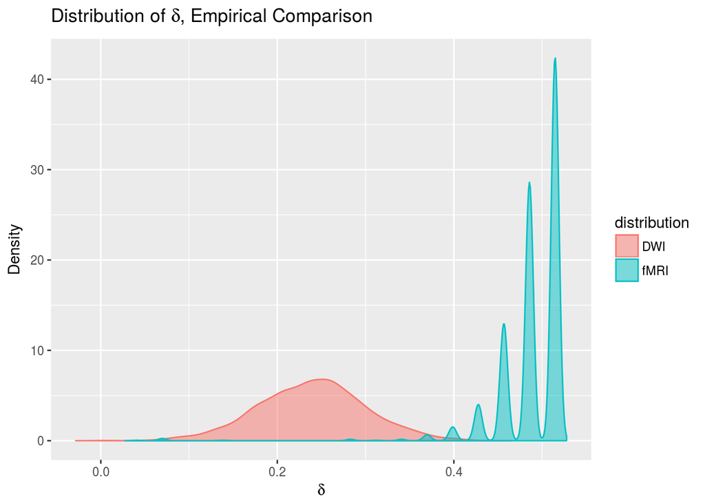

```r
cmp.emp = data.frame(x = c(dwi.distr.emp.mod$x, fmri.distr.emp.mod$x), y = c(dwi.distr.emp.mod$y, fmri.distr.emp.mod$y),
                     distribution=c(rep("DWI", n_diff), rep("fMRI", n_diff)))

ggplot(dat=cmp.emp, aes(x=x, y=y, ymax=y, fill=distribution, color=distribution, group=distribution)) +
  geom_ribbon(ymin=0, alpha=0.5) +
  ylab('Density') +
  xlab(TeX('$\\delta$')) +
  ggtitle(TeX('Distribution of $\\delta$, Empirical Comparison'))
```

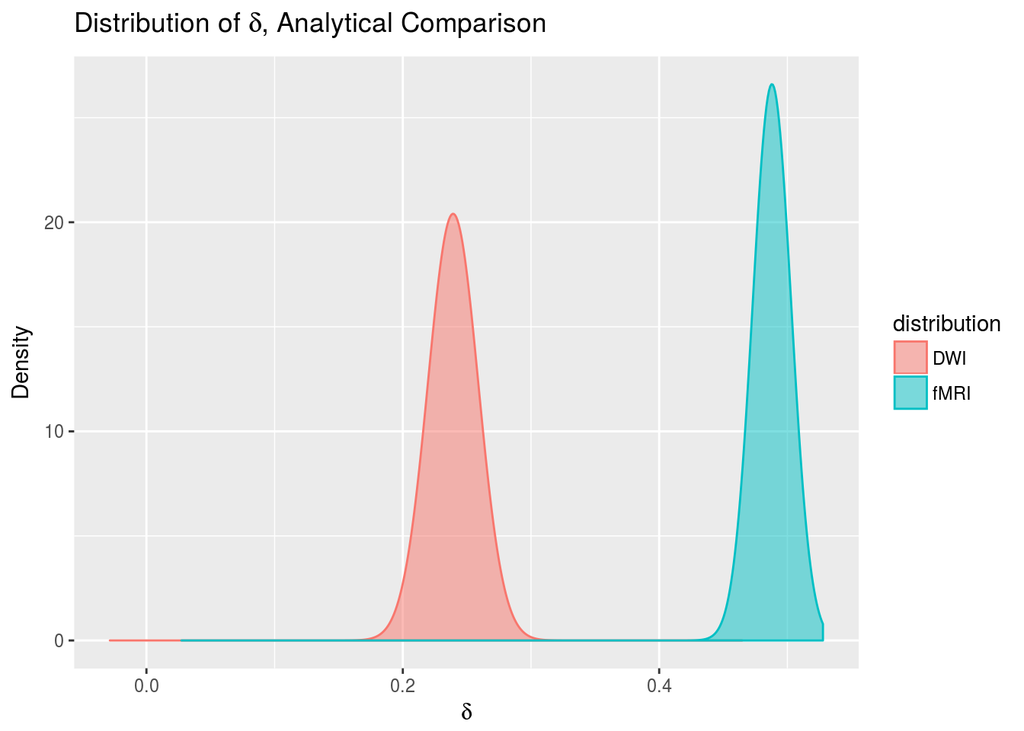

```r
cmp.ana = data.frame(x = c(dwi.distr.emp.mod$x, fmri.distr.emp.mod$x), y = c(dwi.distr.ana, fmri.distr.ana),
                     distribution=c(rep("DWI", n_diff), rep("fMRI", n_diff)))

ggplot(dat=cmp.ana, aes(x=x, y=y, ymax=y, fill=distribution, color=distribution, group=distribution)) +
  geom_ribbon(ymin=0, alpha=0.5) +
  ylab('Density') +
  xlab(TeX('$\\delta$')) +
  ggtitle(TeX('Distribution of $\\delta$, Analytical Comparison'))
```

both the empirical and analytical results show clear separation of $\delta_D$ and $\delta_F$. Performing a $t-$test of this observation, we see:

```r
t.test(fmri.delta, dwi.delta, alternative="greater", var.equal=FALSE)
```

```
##
##  Welch Two Sample t-test
##
## data:  fmri.delta and dwi.delta
## t = 167.8, df = 4630.1, p-value < 2.2e-16
## alternative hypothesis: true difference in means is greater than 0
## 95 percent confidence interval:
##  0.2463029       Inf
## sample estimates:
## mean of x mean of y
## 0.4879711 0.2392294
```

which shows that with $p < 2.2 \times 10^{-16}$, the difference in connectivity bi-laterally vs. non bi-laterally in functional connectomes exceeds the difference in connectivity bi-laterally vs non bi-laterally in diffusion connectomes.

### Comparing p-value per subject of Functional vs Diffusion $\hat{\delta}$ (one p-value per pair)

Below, we compute a $p-$value given 2 graphs, 1 functional and 1 diffusion, from the same subject, where we take the cartesian product of the functional connectomes with the diffusion connectomes for each subject. For example, if we had $2$ functional connectomes and $2$ diffusion connectomes, we would end up with $4$ $p-$values, with the first functional connectome $\delta$ compared with the first diffusion connectome $\delta$ ($11$ comparison), and so on for $12$ (first functional connectome with second diffusion connectome), $21$, $22$. We plot a distribution of the $p-$values for each dataset:

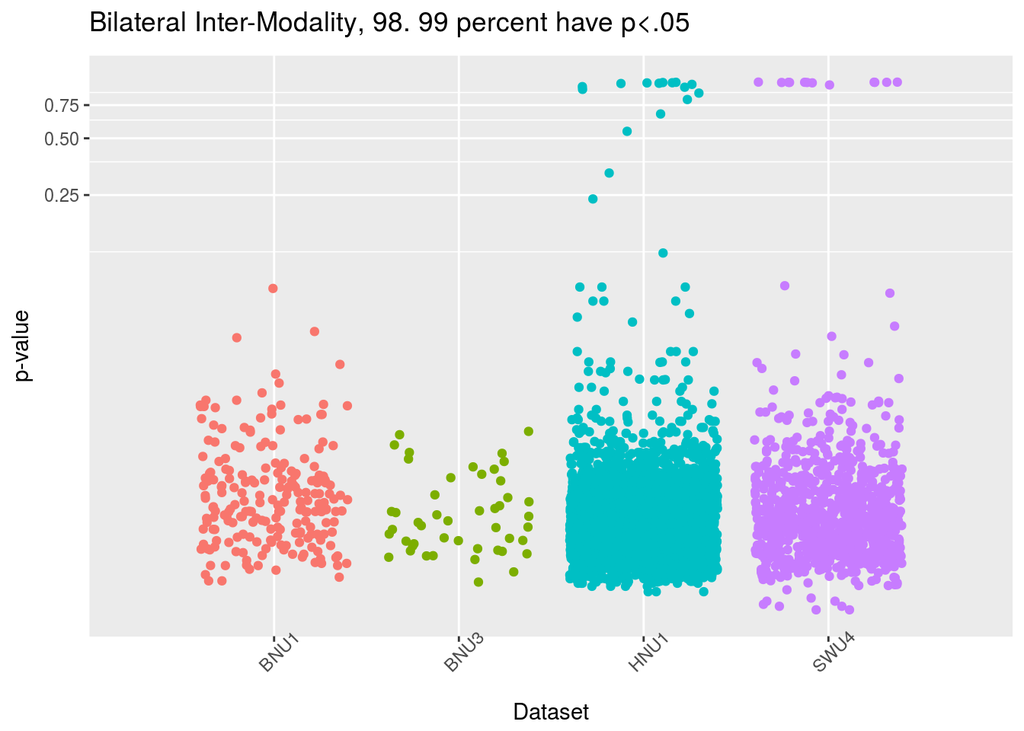

```r
# find the common datasets
common.dsets = fmri.dsets[which(fmri.dsets %in% dwi.dsets)]
# find the common subjects
common.sub.sid = fmri.subjects[which(fmri.subjects %in% dwi.subjects)]
common.sub.did = fmri.datasets[which(fmri.subjects %in% dwi.subjects)]

per.p <- c()
per.dataset <- c()
per.subject <- c()
fmri.failed <- c()
dwi.failed <- c()
p.failed <- c()
per.dwi.delta <- c()
per.fmri.delta <- c()
unique_subs = unique(common.sub.sid)
for (i in 1:length(unique_subs)) {
  sub = unique_subs[i]
  dset = unique(fmri.datasets[which(fmri.subjects == sub)])
  fmri.idxs = which(fmri.subjects == sub)
  dwi.idxs = which(dwi.subjects == sub)
  for (fidx in fmri.idxs) {
    for (didx in dwi.idxs) {
      pval <- ana.welch_ttest(fmri.delta[fidx], dwi.delta[didx], fmri.per.var[fidx], dwi.per.var[didx], ns=1, ns2=1, df=2)$p
      per.dwi.delta <- c(per.dwi.delta, dwi.delta[didx])
      per.fmri.delta <- c(per.fmri.delta, fmri.delta[fidx])
      per.p <- c(per.p, pval)
      per.dataset <- c(per.dataset, dset)
      per.subject <- c(per.subject, sub)
      if (pval > .05) {
        fmri.failed <- c(fmri.failed, fidx)
        dwi.failed <- c(dwi.failed, didx)
        p.failed <- c(p.failed, pval)
      }
    }
  }
}

p.dat <- data.frame(p = per.p, dataset=per.dataset, subject=per.subject)
p.dat$dataset <- factor(p.dat$dataset)
ggplot(data=p.dat, aes(x=dataset, y=p, color=dataset, group=dataset)) +
  geom_jitter() +
  coord_trans(y = "log10") +
  ggtitle(TeX(sprintf('Bilateral Inter-Modality, %.2f percent have $p < .05$', 100*sum(per.p < .05)/length(per.p)))) +
  xlab('Dataset') +
  ylab('p-value') +
  theme(axis.text.x = element_text(angle=45), legend.position=NaN)
```

As we can see, even at just the $2-$graph level, the difference in bi-lateral vs. non bi-lateral connectivity in the functional vs. diffusion connectomes is significant in most connectome pairs at $\alpha=0.05$.

##### Example of subject with $p > .05$

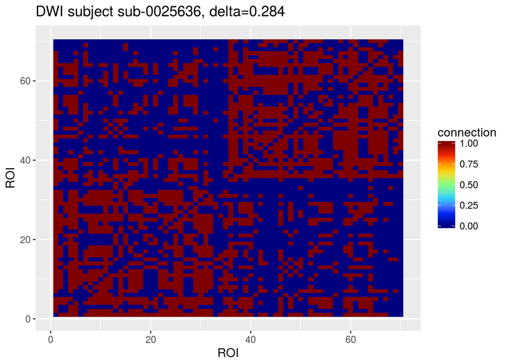

```r
sort_p <- sort(p.failed, index.return=TRUE, decreasing = TRUE)
ix = sort_p$ix[1]
dwfailed = thresh_matrix(dwi.graphs[dwi.failed[ix],,], thresh=0)
fmfailed = thresh_matrix(fmri.graphs[fmri.failed[ix],,])
fmriu.plot.plot_graph(dwfailed, include_diag = TRUE,
                      title = sprintf("DWI subject %s, delta=%.3f", as.character(dwi.subjects[dwi.failed[ix]]), dwi.delta[dwi.failed[ix]]),
                      legend.name = "connection")
```

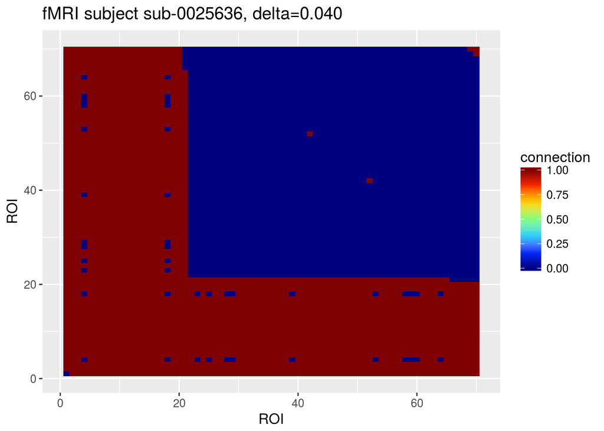

```r
fmriu.plot.plot_graph(fmfailed, include_diag = TRUE,
                      title = sprintf("fMRI subject %s, delta=%.3f", as.character(fmri.subjects[fmri.failed[ix]]), fmri.delta[fmri.failed[ix]]),
                      legend.name = "connection")
```

```r
print(sort_p$x[1])
```

```
## [1] 0.9935914
```

As we can see, this subject appears to be noise.

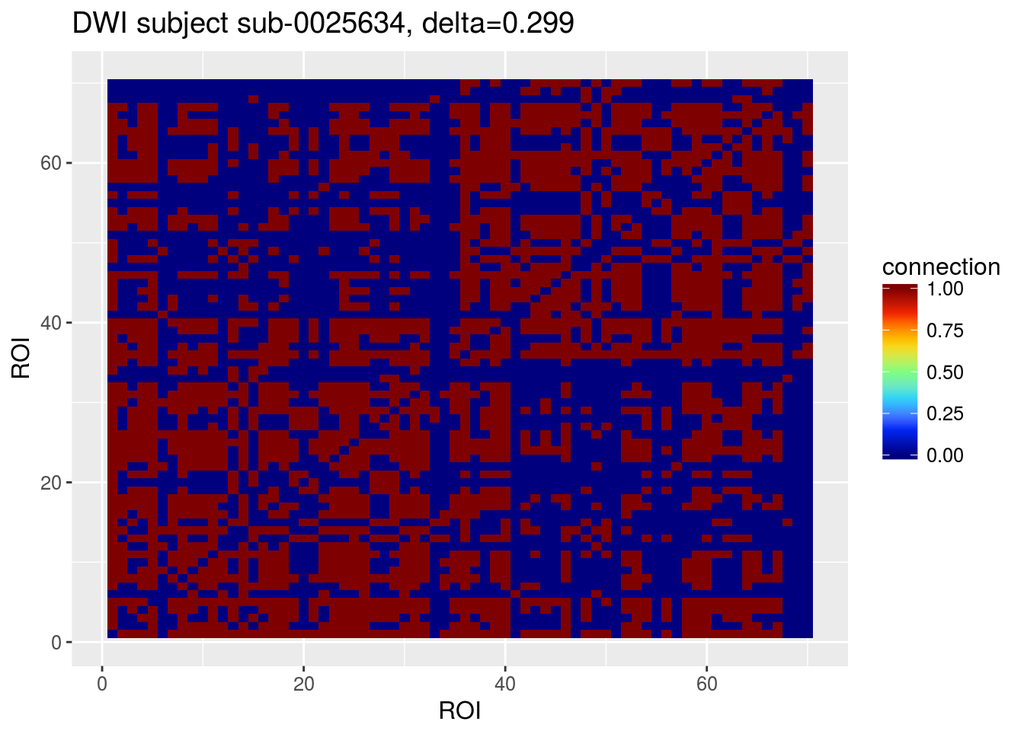

```r
sort_p <- sort(p.failed, index.return=TRUE, decreasing = TRUE)
ix = sort_p$ix[2]
dwfailed = thresh_matrix(dwi.graphs[dwi.failed[ix],,], thresh=0)
fmfailed = thresh_matrix(fmri.graphs[fmri.failed[ix],,])
fmriu.plot.plot_graph(dwfailed, include_diag = TRUE,
                      title = sprintf("DWI subject %s, delta=%.3f", as.character(dwi.subjects[dwi.failed[ix]]), dwi.delta[dwi.failed[ix]]),
                      legend.name = "connection")
```

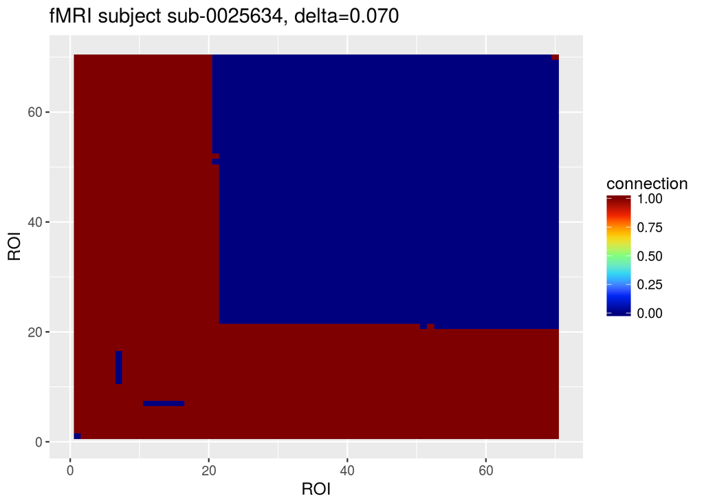

```r
fmriu.plot.plot_graph(fmfailed, include_diag = TRUE,
                      title = sprintf("fMRI subject %s, delta=%.3f", as.character(fmri.subjects[fmri.failed[ix]]), fmri.delta[fmri.failed[ix]]),
                      legend.name = "connection")
```

```r
print(sort_p$x[2])
```

```
## [1] 0.9930109
```

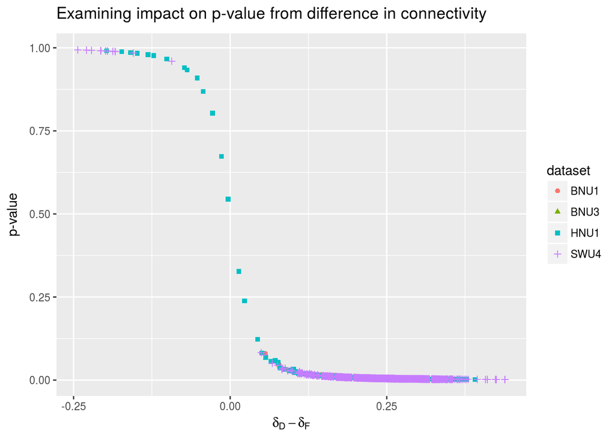

```r
batch.dat <- data.frame(diff= per.fmri.delta - per.dwi.delta, p = per.p, dataset=per.dataset)
batch.dat$dataset <- factor(batch.dat$dataset)
ggplot(batch.dat, aes(x=diff, y=p, color=dataset, group=dataset, shape=dataset)) +
  geom_point() +
  xlab(TeX('$\\delta_D - \\delta_F$')) +
  ylab(TeX('$p-$value')) +
  ggtitle(TeX('Examining impact on $p-$value from difference in connectivity'))
```

### Aggregated

Here, we again perform a test on 2 graphs, except here the graphs used are the average functional and diffusion connectomes (the megameans). We feed this into a simple t-test with the appropriate assumptions (unequal variance, goal is to test for bilateral connectivity exceeding non bilateral connectivity):

```r
fbi = c(fmri_thresh[group1])
fnbi = c(fmri_thresh[group2])
f.bi.p = mean(fbi)
f.nbi.p = mean(fnbi)


dbi = c(dwi_thresh[group1])
dnbi = c(dwi_thresh[group2])
d.bi.p = mean(dbi)
d.nbi.p = mean(dnbi)

ana.welch_ttest(abs(f.bi.p - f.nbi.p), abs(d.bi.p - d.nbi.p),model.var(f.bi.p, ne) + model.var(f.nbi.p, ne),
                model.var(d.bi.p, ne) + model.var(d.nbi.p, ne), ns1=1, ns2=1, df = 2)
```

```
## $t
## [1] 16.99437
##
## $p
## [1] 0.00172231
##
## $df
## [1] 2
```

As we can see above, with just 2 megamean graphs, we can determine a significant difference in the difference in connectivity bi-laterally vs non-bi-laterally in functional connectomes exceeds that of diffusion connectomes.